# 05. Развёртка параметров GEA на бенчмарке MVP — ADAPTOGENE

14 реплик · 4 метода (EMMAX / LFMM / RDA / BLINK) · 5 рунгов коррекции структуры · сетка порогов × правила объединения

## Обзор

Обзор файла: измерение компромисса «сколько истинных адаптивных локусов найдено / сколько ложноположительных» на 14 симуляционных репликах MVP — как функции метода GEA, рунга коррекции популяционной структуры, порога значимости и правила объединения методов. Заявка пайплайна состоит в том, что пользователь, который может гонять несколько методов, крутить их коррекцию структуры и объединять вызовы на пороге, выбранном по манхэттен-плоту, вытаскивает больше истинных локусов при той же цене ложных, чем любой одиночный метод на дефолтах.

```bash
if [ ! -f /mnt/data/eugene/ADAPTOGENE/work/journal/diagrams/05_00_abstract.svg ] || \
   [ /mnt/data/eugene/ADAPTOGENE/work/journal/diagrams/05_00_abstract.d2 -nt \
     /mnt/data/eugene/ADAPTOGENE/work/journal/diagrams/05_00_abstract.svg ]; then
  d2 --theme 200 --layout elk \
    /mnt/data/eugene/ADAPTOGENE/work/journal/diagrams/05_00_abstract.d2 \
    /mnt/data/eugene/ADAPTOGENE/work/journal/diagrams/05_00_abstract.svg
fi
```

[figure not shown]

## 1. Что именно измеряется, и три конфигурации

Единица наблюдения — **операционная точка**: кортеж (реплика, метод, рунг, правило порога, правило объединения). Для каждой считаются `precision_strict`, `recall_testable`, `F1` и число вызовов, по таблице истины реплики.

**Метрика точности — `precision_strict`.** Ложноположительными считаются ТОЛЬКО локусы категории `background_neutral` (группы сцепления 11–20). Это собственная конвенция исходной статьи (Lotterhos 2023, Methods: *«the performance statistics were calculated by only including truly neutral loci unaffected by selection on linkage groups 11 to 20 and the QTNs»*) и она же реализована в `benchmarks/lib_detection.R`. `precision_all` выводится рядом для прозрачности: примерно половина генома — `linked_neutral`, поэтому две метрики расходятся сильно.

**Контракт скоринга** (`benchmarks/MVP_README.md:41-62`) — единственное, что здесь легко испортить необратимо, потому что неверная пара «таблица истины × предиктор» молча превращает настоящие детекции в ложноположительные:

- EMMAX / LFMM / BLINK → `truth_temp.tsv` + `bio_1` (частично конфаундированная ось), `truth_sal.tsv` + `bio_2` (ортогональный контроль), `truth_any.tsv` + `all`
- RDA → **только** `truth_any.tsv` + `all`: `rda.R:689` пишет одну колонку `climate_multivariate`, поосевого p-значения не существует

**Три конфигурации, которые нельзя смешивать:**

- **default** — ячейка `c3`, все методы на `sNMF.k_best`. То, что пайплайн делает, если пользователь ничего не трогает.
- **pregea** — каждый метод на рунге, который порекомендовал `mode=pregea`. Таблица истины не используется. **Это достижимая конфигурация**, и именно на ней держится заявка.
- **oracle** — каждый метод на рунге с максимальным AUC-PR *по таблице истины*. **Верхняя граница и ничего больше**: у пользователя таблицы истины нет. Подавать её как «производительность пайплайна» означало бы свести всё утверждение к «зная ответ, легче найти ответ». Она нужна только чтобы измерить, сколько `pregea` оставляет на столе.

## 2. Лестницы рунгов и генерация ячеек

**R 4.5 / data.table** в контейнере `adaptogene:latest`, скрипт `/mnt/data/eugene/ADAPTOGENE/benchmarks/mvp_write_sweep_configs.R`.

Причина, по которой развёртка вообще требует отдельных конфигов: пайплайн запрещает повторяющиеся имена методов внутри одного `GEA.configs` (`workflow/rules/common.smk:404`), а имя выходного файла `{method}_pvalues_K{k_best}.tsv` кодирует `sNMF.k_best` и **никогда** — сам развёртываемый параметр (`common.smk:1308`). Значит одна лестница = один прогон `mode=gea` на рунг, с выносом таблиц между прогонами.

- `k` = `sNMF.k_best` реплики (2–7, из колонки `K` самого депозита, с полом 2)
- **лестница `n_pcs`** (EMMAX `n_pcs`, RDA `condition_pcs`, BLINK `n_pcs` → число PC-ковариат): `{0, round(k/2), k, 2k, min(20, 4k)}`
- **лестница LFMM `K`**: `{k-2, k-1, k, k+2, k+4}`, обрезано в `[1,20]`, дедуплицировано и дополнено вверх до 5 различных рунгов (при `k=2` иначе `c1` и `c2` схлопнулись бы на `K=1` и ячейка молча пересчитывала бы ту же подгонку)
- `c3` — дефолтный рунг пайплайна (сентинел `@k_best`, `workflow/methods/gea.py:43`)
- `c1` (0 PC) — самый нагруженный рунг именно на этих данных: сиды отбирались по R²(PC1~temp) ∈ [0.30, 0.60], то есть коррекции структуры есть что делать. Он же воспроизводит нескорректированное плечо RDA у Lotterhos: при `condition_pcs=0` второй подгонки нет и правило `pmax` вырождается в тождество

Ячейка — приём амортизации счёта, а **не** совместная конфигурация под тестом: ячейка *i* просто ставит каждый метод на его собственный *i*-й рунг, чтобы один прогон дал по рунгу для каждого из четырёх методов. Лестницы скорятся независимо; смешанные наборы (`oracle`, `pregea`) снимают это ограничение.

Каждый выходной конфиг — это базовый конфиг реплики с заменённым **только** блоком `GEA:`. `project_name` не меняется, поэтому upstream (`processing`→`prestructure`→`structure`) считается один раз на реплику и переиспользуется всеми ячейками. `Input.*` побайтово совпадает между ячейками одной реплики, поэтому предупреждение `CLAUDE.md` про два конфига с одним `project_name`, смотрящих на разные сырые данные, здесь не срабатывает — они смотрят на одни и те же данные намеренно.

```r
check_files(c(
  "/mnt/data/eugene/ADAPTOGENE/benchmarks/mvp_write_sweep_configs.R",
  "/mnt/data/eugene/ADAPTOGENE/benchmarks/mvp_sweep_cells.tsv",
  "/mnt/data/eugene/ADAPTOGENE/config_MVP1232548_c1.yaml",
  "/mnt/data/eugene/ADAPTOGENE/config_MVP1232548_c5.yaml"))
```

```
## [OK] /mnt/data/eugene/ADAPTOGENE/benchmarks/mvp_write_sweep_configs.R
## [OK] /mnt/data/eugene/ADAPTOGENE/benchmarks/mvp_sweep_cells.tsv
## [OK] /mnt/data/eugene/ADAPTOGENE/config_MVP1232548_c1.yaml
## [OK] /mnt/data/eugene/ADAPTOGENE/config_MVP1232548_c5.yaml
```

```bash
# НЕ ПЕРЕЗАПУСКАТЬ — выполнено 2026-08-02
nix shell nixpkgs#docker-client -c docker run --user $(id -u):$(id -g) --rm -e USER=pipeline \
  -v /mnt/data/eugene/ADAPTOGENE:/pipeline adaptogene:latest \
  Rscript /pipeline/benchmarks/mvp_write_sweep_configs.R
```

```
## Строк в манифесте: 280 (ожидается 14 x 5 x 4 = 280)
##
##        seed k_best method     рунги
##      <char>  <int> <char>    <char>
##  1: 1231288      2  BLINK 0,1,2,4,8
##  2: 1231288      2  EMMAX 0,1,2,4,8
##  3: 1231288      2   LFMM 1,2,4,6,8
##  4: 1231288      2    RDA 0,1,2,4,8
##  5: 1231578      2  BLINK 0,1,2,4,8
##  6: 1231578      2  EMMAX 0,1,2,4,8
##  7: 1231578      2   LFMM 1,2,4,6,8
##  8: 1231578      2    RDA 0,1,2,4,8
##  9: 1231993      2  BLINK 0,1,2,4,8
## 10: 1231993      2  EMMAX 0,1,2,4,8
## 11: 1231993      2   LFMM 1,2,4,6,8
## 12: 1231993      2    RDA 0,1,2,4,8
```

Сгенерировано **70** конфигов (14 реплик × 5 ячеек), манифест — **280** строк (14 × 5 × 4 метода). Три гейта пройдены на всех 70: `project_name` и блок `Input` побайтово совпадают с базовым конфигом реплики, и `GEA` — **единственный** изменившийся ключ верхнего уровня.

Примеры лестниц: `k=2` → `n_pcs` [0,1,2,4,8], LFMM K [1,2,4,6,8]; `k=5` (реплика 1232548) → `n_pcs` [0,2,5,10,20], LFMM K [3,4,5,7,9]; `k=7` (реплика 1232578) → `n_pcs` [0,4,7,14,20] (4k=28 обрезано до потолка 20), LFMM K [5,6,7,9,11].

## 3. Расширение сетки порогов

Правка в `/mnt/data/eugene/ADAPTOGENE/benchmarks/sweep_thresholds.R`: константа `GRID` и вектор top-N для правила `rank_sum`. Больше в файле не изменено ничего.

| правило | было | стало |
| --- | --- | --- |
| `bonf` | 0.01 0.05 0.1 | + 0.5 **1** |
| `qval` | 0.05 0.1 0.2 0.3 | + 0.4 0.5 |
| `top` | 10 20 30 50 100 | + 200 500 **1000** |
| `custom` | 1e-5 1e-4 1e-3 | + **1e-6** 1e-2 |
| `rank_sum` top-N | …200 | + 500 1000 |

```r
check_files(c(
  "/mnt/data/eugene/ADAPTOGENE/benchmarks/sweep_thresholds.R",
  "/mnt/data/eugene/ADAPTOGENE/benchmarks/lib_detection.R",
  "/mnt/data/eugene/ADAPTOGENE/benchmarks/eval_detection.R"))
```

```
## [OK] /mnt/data/eugene/ADAPTOGENE/benchmarks/sweep_thresholds.R
## [OK] /mnt/data/eugene/ADAPTOGENE/benchmarks/lib_detection.R
## [OK] /mnt/data/eugene/ADAPTOGENE/benchmarks/eval_detection.R
```

Расширенная сетка проверена на уже собранных таблицах реплики 1232548 (`truth_any`, 70 каузальных из 10 325 SNP) — отрабатывает без ошибок.

Отдельно **эмпирически закреплён путь с нулём каузальных локусов**: у четырёх однопризнаковых реплик (1231858, 1232908, 1233133, 1233208) на оси `bio_2` каузальных локусов **ноль**, что делает эту ось чистым контролем ложноположительных. `eval_detection.R:74` на таком входе падает специально, поэтому rank-режим для них пропускается; `sweep_thresholds.R` такой защиты не имеет и был прогнан на настоящей нулевой таблице истины — выходит с кодом 0, пишет сводную TSV, `precision`/`recall` корректно NaN, осмысленные колонки — `n_called` и `fp_background`, а Парето-фронт и график корректно не строятся.

## 4. Два дефекта пайплайна, найденные развёрткой

Оба нашлись на смоук-тесте и оба исправлены после согласования (режим CLAUDE.local.md — «use-only»: находки докладываются, правки не делаются молча).

**Дефект 1 — параметры `GEA.configs` не доходили до LFMM и до GAPIT-моделей.** `workflow/rules/gea.smk:221` передавал в `lfmm.R` глобальный `K_BEST` вместо `GEA_PARAMS['LFMM']['K']`; `gea.smk:348` — то же самое для `params.n_pcs` GAPIT-моделей. Те же строки на стороне GWAS (`gwas.smk:73,113,230,267`). Параметры при этом объявлены в реестре (`workflow/methods/gea.py`), валидируются по диапазону в `_coerce_param`, рекомендуются пользователю через `pregea_recommend.R` и подставляются в редакторе методов Shiny — то есть поверхность выглядит живой со всех сторон, кроме самого правила. Корректно работали только EMMAX (`gea.smk:182`) и RDA.

*Доказательство до правки*: сухой прогон ячейки `c1` перезапускал `assoc_emmax_gea_trait` («Params have changed since last execution: before: 5 now: 0») и `assoc_rda_gea`, но **не** `assoc_lfmm_gea_trait`, хотя LFMM K менялся 5 → 3.

*Обходного пути через конфиг нет*: `sNMF.k_best` управляет ещё и импутацией (`gea.smk:42`), так что сдвиг `k_best` поменял бы импутированную матрицу генотипов, которая питает **все** методы, и смешал бы лестницу с изменением входных данных.

**Дефект 2 — `scripts/gapit.R` падал при `n_pcs = 0`.** `pca_cols <- pca_raw[, 1:K_BEST]` при `K_BEST = 0` даёт `1:0` = `c(1, 0)`, то есть одну колонку, тогда как `paste0("PC", 1:0)` даёт два имени → `Can't assign 2 names to a 1-column data.table`. При этом `workflow/methods/gea.py:64` объявляет `n_pcs` с `min=0`, то есть конфиг легален, но неисполним. Задевает любого пользователя, поставившего `n_pcs: 0` любой GAPIT-модели, и в `mode=gea`, и в `mode=gwas`. EMMAX / LFMM / RDA нулевой рунг переваривают штатно.

```r
check_files(c(
  "/mnt/data/eugene/ADAPTOGENE/workflow/rules/gea.smk",
  "/mnt/data/eugene/ADAPTOGENE/scripts/gapit.R"))
```

```
## [OK] /mnt/data/eugene/ADAPTOGENE/workflow/rules/gea.smk
## [OK] /mnt/data/eugene/ADAPTOGENE/scripts/gapit.R
```

```bash
# НЕ ПЕРЕЗАПУСКАТЬ — выполнено 2026-08-02
# Правка 1: gea.smk:221  k = K_BEST -> k = GEA_PARAMS.get('LFMM', {}).get('K', K_BEST)
# Правка 2: gea.smk:348  k = K_BEST -> k = _gapit_shared_npcs()
#           (новая функция: берёт n_pcs из GEA_PARAMS, жёстко падает, если две
#            сконфигурированные GAPIT-модели просят разное — один вызов gapit.R
#            принимает один скаляр и не может выразить помодельные значения)
# Правка 3: gapit.R      pca_cols/myCV/CV защищены от K_BEST == 0 (CV = NULL,
#                        PCA.total = 0 уже стоял -> подгонка только по родству)

# Проверка, что триггер параметров теперь срабатывает:
nix shell nixpkgs#docker-client -c docker run --user $(id -u):$(id -g) --rm -e USER=pipeline \
  -v /mnt/data/eugene/ADAPTOGENE:/pipeline adaptogene:latest \
  snakemake -n -s Snakefile --config mode=gea \
    --configfile config_MVP1232548_c1.yaml --scheduler greedy
```

После правки сухой прогон `c1` перезапускает `assoc_lfmm_gea_trait` с причиной «Params have changed since last execution: before: 5 now: 3», плюс `assoc_emmax_gea_trait` (5 → 0) и `assoc_rda_gea` (→ 0). Обратная совместимость сохранена: на `c3`, где все рунги равны `k_best`, LFMM/EMMAX/RDA корректно **не** перезапускаются — меняется только добавленный BLINK.

## 5. Смоук-тест: воспроизведение пилота и подключение BLINK

Ячейка `c3` реплики 1232548 (`k_best = 5`) — то есть ровно дефолты пайплайна, на которых был посчитан опубликованный пилот, плюс добавленный четвёртым методом BLINK. Прогон `mode=gea`, контейнер `adaptogene:latest`, `--cpus=32 --memory=200g`, `snakemake -c8`.

Смысл ячейки как теста: EMMAX/LFMM/RDA на `c3` стоят на тех же параметрах, что и пилот, поэтому любое расхождение в AUC-PR означало бы ошибку в тракте выноса таблиц или в генерации конфигов, а не научный результат.

```r
check_files(c(
  "/mnt/data/eugene/ADAPTOGENE/benchmarks/mvp_eval/params/MVP1232548/c3/EMMAX_pvalues.tsv",
  "/mnt/data/eugene/ADAPTOGENE/benchmarks/mvp_eval/params/MVP1232548/c3/LFMM_pvalues.tsv",
  "/mnt/data/eugene/ADAPTOGENE/benchmarks/mvp_eval/params/MVP1232548/c3/RDA_pvalues.tsv",
  "/mnt/data/eugene/ADAPTOGENE/benchmarks/mvp_eval/params/MVP1232548/c3/BLINK_pvalues.tsv",
  "/mnt/data/eugene/ADAPTOGENE/benchmarks/mvp_eval/sweep/MVP1232548/rank.tsv"))
```

```
## [OK] /mnt/data/eugene/ADAPTOGENE/benchmarks/mvp_eval/params/MVP1232548/c3/EMMAX_pvalues.tsv
## [OK] /mnt/data/eugene/ADAPTOGENE/benchmarks/mvp_eval/params/MVP1232548/c3/LFMM_pvalues.tsv
## [OK] /mnt/data/eugene/ADAPTOGENE/benchmarks/mvp_eval/params/MVP1232548/c3/RDA_pvalues.tsv
## [OK] /mnt/data/eugene/ADAPTOGENE/benchmarks/mvp_eval/params/MVP1232548/c3/BLINK_pvalues.tsv
## [OK] /mnt/data/eugene/ADAPTOGENE/benchmarks/mvp_eval/sweep/MVP1232548/rank.tsv
```

```bash
# НЕ ПЕРЕЗАПУСКАТЬ — выполнено 2026-08-02
nix shell nixpkgs#docker-client -c docker run --user $(id -u):$(id -g) --rm -e USER=pipeline \
  --cpus=32 --memory=200g -v /mnt/data/eugene/ADAPTOGENE:/pipeline adaptogene:latest \
  snakemake -c8 -s Snakefile --config mode=gea \
    --configfile config_MVP1232548_c3.yaml --scheduler greedy
```

[output not shown]

[output cut: 40 more lines]

**Воспроизведение точное.** AUC-PR на `c3`: LFMM 0.2221 (temp) / 0.3959 (sal), EMMAX 0.0308 / 0.1042, RDA 0.2223 (any) — против опубликованных в `benchmarks/MVP_README.md` пилотных 0.222 / 0.396, 0.031 / 0.104, 0.222. Тракт выноса таблиц и генерация конфигов подтверждены.

**Гейт склейки с истиной** пройден: `n_causal_testable` = 30 (temp) / 40 (sal) / 70 (any), ровно столько же каузальных локусов, сколько в таблицах истины реплики. Ни один каузальный локус не потерялся между VCF и скорингом.

**BLINK подключён и работает**: заголовок `BLINK_pvalues_K5.tsv` — ровно `SNPID chr pos bio_1 bio_2`, без посторонних колонок GAPIT (это важно: `load_pvalues` считает признаком любую колонку, кроме структурных, и объединил бы вызовы по лишним). 10 325 SNP, полный набор. AUC-PR на `c3` — 0.0143 (temp) / 0.0623 (sal), худший из четырёх методов, чего и следует ожидать от многолокусной модели на конфаундированной оси.

## 6. Потолок по ресурсам: OpenBLAS видит ядра хоста, а не контейнера

Первый прогон ячейки `c1` реплики 1232548 упёрся не в алгоритм, а в конфигурацию контейнера: одна подгонка `vegan::rda(Y ~ bio_1 + bio_2, scale = TRUE)` на матрице 1000 × 10 325 **крутилась больше 27 минут и доросла до 81 ГБ резидентной памяти, так и не завершившись**, при этом контейнер держал всего ~450 % CPU из выделенных 32 ядер.

Причина: `--cpus=N` **не меняет** то, что контейнер читает из `/proc/cpuinfo` — `nproc` внутри возвращает **192** (число ядер хоста). Образ слинкован с OpenBLAS-pthread (`/usr/lib/x86_64-linux-gnu/openblas-pthread/libopenblasp-r0.3.26.so`), который поэтому порождает 192 потока, дерущихся за долю CPU контейнера, и каждый аллоцирует свои буферы — отсюда и время, и память.

Замер внутри образа, `crossprod` + `svd` матрицы 1500 × 1500, `--cpus=32`:

| `OPENBLAS_NUM_THREADS` | время |
| --- | --- |
| не задан (192 потока) | **52.65 с** |
| 1 | 3.16 с |
| 8 | 1.42 с |
| 16 | **1.30 с — в 40 раз быстрее, чем не задан** |

Лечится флагом `docker run`, а не правкой пайплайна: `-e OPENBLAS_NUM_THREADS=16 -e OMP_NUM_THREADS=16`.

Значение **зафиксировано и одинаково во всех прогонах развёртки** (`BLAS_THREADS` в `benchmarks/mvp_run_sweep.sh`): число потоков BLAS может менять порядок суммирования с плавающей точкой, поэтому смешивать настройки внутри одного бенчмарка — дыра в воспроизводимости. Отсюда же требование проверить, что результаты от этого не поехали (ниже).

```r
check_files(c(
  "/mnt/data/eugene/ADAPTOGENE/benchmarks/mvp_run_sweep.sh",
  "/mnt/data/eugene/ADAPTOGENE/benchmarks/mvp_score_sweep.sh",
  "/mnt/data/eugene/ADAPTOGENE/benchmarks/mvp_pick_bundles.R",
  "/mnt/data/eugene/ADAPTOGENE/benchmarks/mvp_sweep_report.R"))
```

```
## [OK] /mnt/data/eugene/ADAPTOGENE/benchmarks/mvp_run_sweep.sh
## [OK] /mnt/data/eugene/ADAPTOGENE/benchmarks/mvp_score_sweep.sh
## [OK] /mnt/data/eugene/ADAPTOGENE/benchmarks/mvp_pick_bundles.R
## [OK] /mnt/data/eugene/ADAPTOGENE/benchmarks/mvp_sweep_report.R
```

```bash
# НЕ ПЕРЕЗАПУСКАТЬ — выполнено 2026-08-02
# Замер потоков BLAS внутри образа:
for T in 1 8 16 32; do
  nix shell nixpkgs#docker-client -c docker run --rm --user $(id -u):$(id -g) -e USER=pipeline \
    --cpus=32 -e OPENBLAS_NUM_THREADS=$T -e OMP_NUM_THREADS=$T adaptogene:latest \
    Rscript -e 'n<-1500; set.seed(1); A<-matrix(rnorm(n*n),n);
                cat(round(system.time({svd(crossprod(A))})[["elapsed"]],2),"s\n")'
done

# Перепрогон ячейки c3 с исправленной многопоточностью — сверка с числами пилота:
nix shell nixpkgs#docker-client -c docker run --user $(id -u):$(id -g) --rm -e USER=pipeline \
  -e OPENBLAS_NUM_THREADS=16 -e OMP_NUM_THREADS=16 \
  --cpus=32 --memory=200g -v /mnt/data/eugene/ADAPTOGENE:/pipeline adaptogene:latest \
  snakemake -c8 -s Snakefile --config mode=gea \
    --configfile config_MVP1232548_c3.yaml --scheduler greedy
```

## 7. Третий дефект: PopLDdecay падает на мономорфных субпопуляциях

`mode=structure` при `LDdecay.group_by: site` гоняет PopLDdecay по каждому дему × каждой хромосоме: 20 групп сцепления × 101 группа (All + 100 демов) ≈ **2 020 вызовов на реплику**.

На данных MVP это гарантированно натыкается на вырожденный случай: дем — это 10 особей, а группа сцепления — 50 кб с ~250–500 SNP, поэтому часть сочетаний «дем × хромосома» полностью мономорфна. PopLDdecay отфильтровывает все сайты как небиаллельные/синглтонные, остаётся 0 SNP, и вместо пустого результата бинарник **падает с SIGSEGV** (`rc = 139`).

Воспроизведено детерминированно на реплике 1232218, `deme_008`, группа сцепления 1: `total skip allelic sites number is :491` — то есть все 491 сайт хромосомы отброшены. Первый прогон и повтор упали в одной и той же точке; отдельно взятый вызов на дем с полиморфизмом отрабатывает штатно (`EXIT=0`), так что дело в данных субпопуляции, а не в окружении.

Почему это блокирует развёртку, а не только графики LD: правило `ld_decay_run_chr` лежит **на критическом пути `mode=gea`** — `common.smk:1862` кладёт `O['ld_decay_table']` в цели GEA. В логе Snakemake это выглядит как `Error in rule ld_decay_run_chr: message: None`, без указания на настоящую причину.

**Обход — только конфигом, без правки пайплайна.** `LDdecay.scope: "genome_wide"` убирает правило из DAG (`structure.smk:327` гейтит его по scope), сохраняя при этом `ld_decay_table` — единственный продукт LD-decay, который вообще читают правила GEA (`_assoc_downstream.smk:89-111`, группа `All`). Полногеномный прогон объединяет все 20 групп сцепления (5–13 тыс. SNP), поэтому ни один дем из 10 особей там не мономорфен — этот шаг штатно проходит на всех репликах. Поосевые кривые LD-decay — побочный продукт `mode=structure`, к бенчмарку GEA отношения не имеющий.

Побочная выгода: с критического пути уходит ~2 000 вызовов PopLDdecay на реплику.

```r
check_files(c(
  "/mnt/data/eugene/ADAPTOGENE/config_MVP1232218_c1.yaml",
  "/mnt/data/eugene/ADAPTOGENE/config_MVP1232218.yaml"))
```

```
## [OK] /mnt/data/eugene/ADAPTOGENE/config_MVP1232218_c1.yaml
## [OK] /mnt/data/eugene/ADAPTOGENE/config_MVP1232218.yaml
```

```bash
# НЕ ПЕРЕЗАПУСКАТЬ — выполнено 2026-08-02
# Локализация: прогнать все 100 демов на группе сцепления 1 и найти ненулевой код возврата.
nix shell nixpkgs#docker-client -c docker run --user $(id -u):$(id -g) --rm -e USER=pipeline \
  -v /mnt/data/eugene/ADAPTOGENE:/pipeline adaptogene:latest bash -c '
D=/pipeline/MVP1232218_results/_intermediate/ld_decay/grpsite_min10_dist50
for sl in $D/sample_lists/*.txt; do
  g=$(basename "$sl" .txt); [ "$g" = manifest ] && continue; [ "$g" = All ] && continue
  PopLDdecay -InVCF $D/chr_vcfs/1.vcf -OutStat /tmp/probe/${g}_1 \
             -MaxDist 50 -MAF 0 -Miss 1 -Het 1 -SubPop "$sl" >/dev/null 2>&1 \
    || { echo "NONZERO rc=$? group=$g"; break; }
done'
# -> NONZERO rc=139 group=deme_008
```

После правки конфига DAG `mode=gea` содержит только `ld_decay_prepare`, `ld_decay_run_gw` и `ld_decay_analyze` — падающего `ld_decay_run_chr` в нём нет. Базовые конфиги реплик не тронуты (`scope: "both"` в них сохранён); правка живёт только в 70 сгенерированных конфигах ячеек, где от базового отличаются ровно два ключа верхнего уровня — `GEA` и `LDdecay`.

**Замечание о воспроизводимости прогонов.** Upstream (`processing` / `prestructure` / `structure`) 13 реплик считался при незаданном числе потоков BLAS, как и upstream реплики 1232548, посчитанный ранее — то есть все 14 согласованы между собой. Все прогоны `mode=gea` идут при `OPENBLAS_NUM_THREADS=16`. Следствие, которое стоит держать в голове: частичная пересборка upstream отдельной реплики в будущем придёт уже с 16 потоками и будет отличаться от соседей на уровне младших разрядов. Величина этого расхождения измерена в разделе 8.

## 8. Стоимость RDA и две настройки, проверенные на нейтральность

После починки потоков BLAS одна ячейка всё равно шла больше часа. Профилирование (`/mnt/data/eugene/ADAPTOGENE/benchmarks/probe_rda_cost.R`, 1000 особей × 4000 SNP, 16 потоков BLAS) показало, что дело не в линейной алгебре:

| шаг | время |
| --- | --- |
| `rda()` — сама ординация | **4.5 с** |
| `anova.cca` полная модель, `parallel=8` | 5.4 с |
| `anova.cca by="axis"` — **однопоточно** | **112.1 с** |
| `anova.cca by="margin"` — **однопоточно** | **88.2 с** |
| **итого anova** | **205.7 с = 98 % стоимости** |

Два дорогих вызова (`rda.R:323,328`) не получают аргумента `parallel=`, поэтому остаются однопоточными независимо от числа ядер контейнера. При `permutations: 999` этот блок — около 35 мин на 4 тыс. SNP и ~90 мин на подгонку для полного набора 10–13 тыс. SNP, а ячейки c2–c5 подгоняют **дважды**: ~3 часа на ячейку, что и наблюдалось.

**Почему `permutations: 99` не меняет ни одного скорингового числа.** anova питает только `RDA_anova.tsv` (диагностика) и выбор `axes: auto`. При двух предикторах ранг связанной части равен 2, а `rda.R` ограничивает выбор рангом и снизу двойкой — то есть `K_sel` равен 2 при любом исходе теста. Это тот же фиксированный K, который использовали Lotterhos 2023 (`rdadapt(rdaout, 2)`, `MVP_README.md:278`). Скорируемые p-значения приходят из `rdadapt` по этим осям, а не из перестановочного теста.

```r
check_files(c(
  "/mnt/data/eugene/ADAPTOGENE/benchmarks/probe_rda_cost.R",
  "/mnt/data/eugene/ADAPTOGENE/benchmarks/ram_watchdog.sh",
  "/mnt/data/eugene/ADAPTOGENE/benchmarks/mvp_autoscore.sh"))
```

```
## [OK] /mnt/data/eugene/ADAPTOGENE/benchmarks/probe_rda_cost.R
## [OK] /mnt/data/eugene/ADAPTOGENE/benchmarks/ram_watchdog.sh
## [OK] /mnt/data/eugene/ADAPTOGENE/benchmarks/mvp_autoscore.sh
```

```bash
# НЕ ПЕРЕЗАПУСКАТЬ — выполнено 2026-08-02
# Профиль стоимости RDA:
nix shell nixpkgs#docker-client -c docker run --user $(id -u):$(id -g) --rm -e USER=pipeline \
  -e OPENBLAS_NUM_THREADS=16 -e OMP_NUM_THREADS=16 --cpus=16 --memory=40g \
  -v /mnt/data/eugene/ADAPTOGENE:/pipeline adaptogene:latest \
  Rscript /pipeline/benchmarks/probe_rda_cost.R --snps=4000 --perms=99

# Проверка нейтральности: тот же прогон ячейки c3 при 99 перестановках и 16 потоках BLAS,
# сверка таблицы p-значений RDA с эталоном при 999 перестановках и незаданных потоках.
```

**Обе настройки проверены сравнением, а не декларацией.** Ячейка `c3` реплики 1232548, прогнанная при `permutations: 99` и `OPENBLAS_NUM_THREADS=16`, против сохранённого эталона при 999 перестановках и незаданном числе потоков — 10 325 SNP, ключи совпадают полностью:

- максимальное абсолютное расхождение p-значений **1.2e-14**
- максимальное относительное расхождение **2.4e-14**
- **AUC-PR = 0.222302 против 0.222302** — совпадение до шестого знака

Расхождение порядка 1e-14 — это шум двойной точности (eps ≈ 2.2e-16, накопленный по матричным операциям), он не может сдвинуть ни один ранг и ни одно пороговое решение. Одно сравнение закрывает сразу оба вопроса: и число потоков BLAS, и число перестановок нейтральны для скорируемого результата.

Время ячейки: **>1 ч → ~8 мин**.

**Сторожевой процесс по памяти.** Машина общая: на ней параллельно шла чужая сборка генома (NextDenovo, 15 процессов `minimap2-nd` от пользователя `nobody`, ~390 ГБ из 1007 ГБ). На время развёртки поднят `benchmarks/ram_watchdog.sh` с порогом 920 ГБ по метрике `MemTotal - MemAvailable`. Два структурных ограничения, а не соглашения: (1) кандидатами на остановку являются **только docker-контейнеры**, поэтому чужие процессы недостижимы для скрипта в принципе; (2) у контейнера должен совпадать `Config.User` с текущим uid. Остановка — `docker stop -t 10`, не `kill -9`, чтобы snakemake успел убрать частичные выходы; не более двух остановок за цикл опроса. За всю развёртку сторож не сработал ни разу.

## 9. Лестница коррекции структуры: насколько дорог неверный рунг

Скоринг: `benchmarks/mvp_score_sweep.sh` (rank-режим `eval_detection.R` на каждую пару метод × ось, затем `sweep_thresholds.R` на связку методов внутри ячейки), агрегация — `benchmarks/mvp_sweep_report.R`. Оценка ранжирования — AUC-PR, потому что она не зависит от выбора порога и потому что для RDA порог на этих данных не срабатывает вовсе (`MVP_README.md:283-306`: `pmax` двух ~равномерных p-значений даёт корректный **порядок**, но не корректное p-значение).

```r
check_files(c(
  "/mnt/data/eugene/ADAPTOGENE/benchmarks/mvp_eval/report/mvp_ladders.tsv",
  "/mnt/data/eugene/ADAPTOGENE/benchmarks/mvp_eval/report/multimethod_advantage.tsv",
  "/mnt/data/eugene/ADAPTOGENE/benchmarks/mvp_eval/report/published_comparison.tsv",
  "/mnt/data/eugene/ADAPTOGENE/benchmarks/mvp_eval/report/fp_control_sal.tsv",
  "/mnt/data/eugene/ADAPTOGENE/benchmarks/mvp_eval/report/ladder_aucpr.png"))
```

```
## [OK] /mnt/data/eugene/ADAPTOGENE/benchmarks/mvp_eval/report/mvp_ladders.tsv
## [OK] /mnt/data/eugene/ADAPTOGENE/benchmarks/mvp_eval/report/multimethod_advantage.tsv
## [OK] /mnt/data/eugene/ADAPTOGENE/benchmarks/mvp_eval/report/published_comparison.tsv
## [OK] /mnt/data/eugene/ADAPTOGENE/benchmarks/mvp_eval/report/fp_control_sal.tsv
## [OK] /mnt/data/eugene/ADAPTOGENE/benchmarks/mvp_eval/report/ladder_aucpr.png
```

```
## Отношение (лучший рунг / дефолтный рунг) по AUC-PR, сводка по методам:
##
##    method     n median_ratio max_ratio default_is_best
##    <char> <int>        <num>     <num>           <int>
## 1:  EMMAX    38         1.33      5.61               1
## 2:  BLINK    38         1.25    163.30               6
## 3:    RDA    14         1.11      3.80               3
## 4:   LFMM    38         1.09      2.12               4
##
## Реплик x осей, где дефолт НЕ является лучшим рунгом: 114 из 128
```

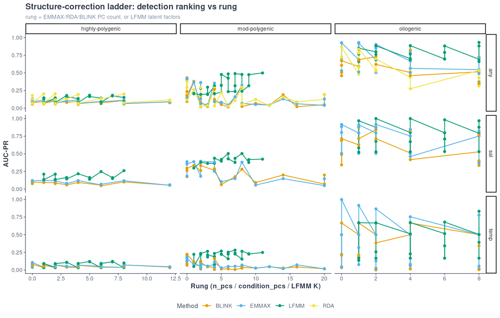

## 10. Объединение методов: когда оно выигрывает, а когда мешает

Сравнение внутри каждой конфигурации отдельно (`default` / `pregea` / `oracle`): лучший одиночный метод против лучшего правила объединения, по F1 и по recall при precision ≥ 0.9.

**Числа из ячейки `c3` НЕ являются свидетельством об объединении.** В `c3` все методы стоят на `k_best`, а это рунг, на котором EMMAX и RDA измеримо плохи, тогда как LFMM близок к своему лучшему. Объединять сильный метод с тремя искалеченными — арифметика, а не свойство объединения. Осмысленное сравнение — внутри `oracle` и `pregea`, где каждый метод стоит на своём рунге.

```
## Доля (реплика x ось), где объединение бьёт лучший одиночный метод, по конфигурациям:
##
##    config_group cells combine_wins  ties median_gain
##          <char> <int>        <int> <int>       <num>
## 1:      default    38           13     4      -0.005
## 2:       oracle    38           14     6       0.000
## 3:       pregea    38           14     5      -0.002
##
## Побеждающие правила:
##
##         combine_f1_kind     N
##                  <char> <int>
## 1:   combine_at_least_2    18
## 2:        combine_union    15
## 3: combine_intersection     6
## 4:     combine_rank_sum     2
##
## Связь с архитектурой (там, где объединение выигрывает):
##
##          arch_level cells  wins
##              <char> <int> <int>
## 1:        oliogenic    36    16
## 2: highly-polygenic    39    14
## 3:    mod-polygenic    39    11
```

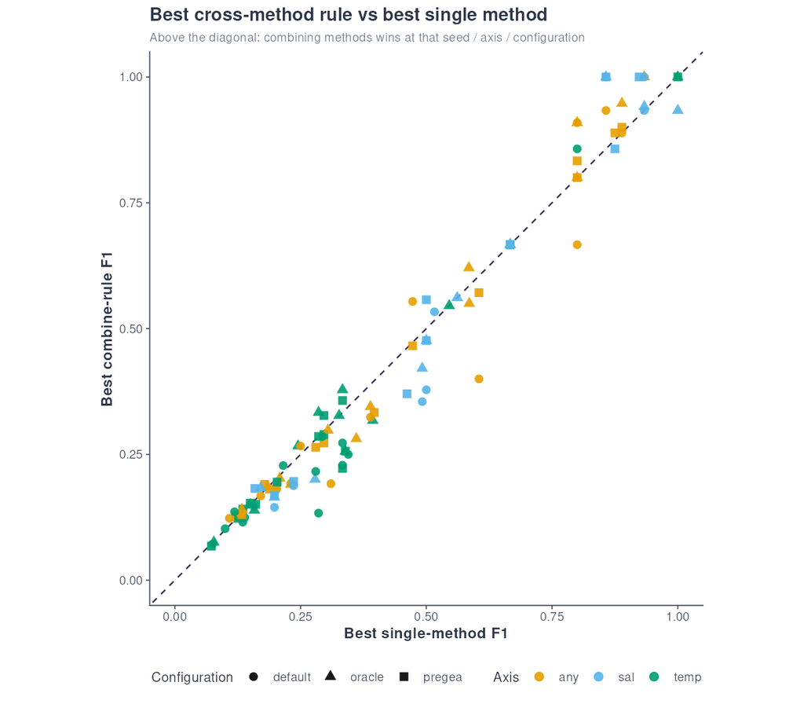

## 11. Достижимая рука: что рекомендует `mode=pregea`

`oracle` выбирает рунг каждого метода по таблице истины — это **верхняя граница**, недостижимая для пользователя. `pregea` берёт рунг из `PreGEA/tables/pregea_recommendations.tsv`, где таблица истины не используется вовсе. Разрыв между ними — цена незнания ответа; разрыв между `default` и `pregea` — то, что рекомендатель реально приносит.

Ограничение, которое нужно называть: ладдеры PreGEA считаются на LD-профильтрованном наборе маркеров, где выживает примерно половина каузальных локусов (реплика 1232548: 30 → 14 по температурной оси). Поэтому PreGEA здесь **номинирует** рунг, а проверяется он всегда на полном наборе в продукционном `mode=gea`. Ни одно число recall из PreGEA не смешивается с продукционной поверхностью.

BLINK собственной рекомендации не имеет (`pregea_recommend.R` выдаёт только LFMM.K, EMMAX.n_pcs, RDA.condition_pcs, RDA.axes, RDA.predictor_set) и наследует `EMMAX.n_pcs` — это буквально та же величина, число PC-ковариат. Помечено в `pregea_cells.tsv` колонкой `inherited`.

```
## Какую долю доступного улучшения (default -> oracle) забирает PreGEA:
##   реплик x осей: 23 | медиана доли: 0.089 | доля случаев, где PreGEA >= default: 0.739
##
##        seed   axis default pregea oracle captured
##      <char> <char>   <num>  <num>  <num>    <num>
##  1: 1232923   temp   0.139  0.161  0.158     1.13
##  2: 1232398   temp   0.800  1.000  1.000     1.00
##  3: 1232548   temp   0.280  0.339  0.339     1.00
##  4: 1232908    any   0.108  0.121  0.121     1.00
##  5: 1232908   temp   0.100  0.127  0.127     1.00
##  6: 1233133    any   0.130  0.133  0.133     1.00
##  7: 1233133   temp   0.119  0.150  0.150     1.00
##  8: 1233208    any   0.250  0.280  0.304     0.55
##  9: 1232923    any   0.171  0.178  0.185     0.55
## 10: 1231993    any   0.857  0.875  0.933     0.23
```

## 12. Контроль ложноположительных: оси без каузальных локусов

У четырёх однопризнаковых реплик (1231858, 1232908, 1233133, 1233208) на оси `bio_2` каузальных локусов ноль. Precision и recall там не определены по построению; осмысленная величина — сколько вызовов делает правило, когда **каждый** из них заведомо ложен.

```
## Медиана числа вызовов на оси без каузальных локусов, по методу/правилу
## (при qval 0.05 и bonf 0.05 — конвенциональные рабочие точки):
##
##                     kind adjust operating_points median_called max_called
##                   <char> <char>            <int>         <num>      <int>
##  1:                BLINK   qval               20          59.0         72
##  2:        combine_union   qval               20          59.0         72
##  3:                BLINK   bonf               20          32.5         46
##  4:        combine_union   bonf               20          32.5         46
##  5:                EMMAX   bonf               20           0.0          1
##  6:                EMMAX   qval               20           0.0          0
##  7:                 LFMM   bonf               20           0.0          0
##  8:                 LFMM   qval               20           0.0          0
##  9:   combine_at_least_2   bonf               20           0.0          1
## 10:   combine_at_least_2   qval               20           0.0          0
## 11: combine_intersection   bonf               20           0.0          0
## 12: combine_intersection   qval               20           0.0          0
```